# 1. Spectral clustering

## 1.1. Eigenvectors of graph Laplacian $L$

Consider an undirected graph with non-negative edge weights $w_{ij}$ and graph Laplacian $L$. Suppose there are $m$ connected components $A_1, A_2, ... ,A_m$ in the graph. Show that there are $m$ eigenvectors of $L$ corresponding to eigenvalue zero, and the indicator vectors of these components $I_{A_1},...I_{A_m}$ span the zero eigenspace.

### Part 1: Eigenvector of the zero eigenvalue of a fully connected graph

Given a Laplacian $L = D - A$:

$$\begin{align} L = \begin{bmatrix} d_{1,1} & -a_{1,2} & \dots & -a_{1,n} \\ -a_{2,1} & d_{2,2} & \dots & -a_{2,n} \\ \vdots & & \ddots & \vdots \\ -a_{m,1} & -a_{m,2} & \dots & d_{m,n} \end{bmatrix} \end{align}$$

For a graph that is fully connected:

- $D$ is the degree matrix whose diagonal elements are the sum of the number of edges for each node
- $A$ is the adjacency matrix, where each row will have a 1 for each node connected to the $i$th node

Therefore, $d_{i,j} = \sum_{j=1}^{n} a_{i,j}$. The degree (the diagonal of $L$) is equal to the sum of adjacency indicators (or edge weights) since the number of edges is the same as the number of connected nodes, for node $i$.

This means that in the Laplacian depicted above, $d_{i,j} + \sum_{j=1}^{n} -a_{i,j} = 0$. It follows that the eigenvector corresponding to the zero eigenvalue will be the vector $\mathbb{1}$ consisting of all 1s:

$$\begin{align} L v &= 0 v \\ L v &= \begin{bmatrix} 0 \\ \vdots \\ 0 \end{bmatrix} \\ \begin{bmatrix} 0 \\ \vdots \\ 0 \end{bmatrix} &= \begin{bmatrix} v_1d_{1,1} - v_2a_{1,2} - \dots - v_na_{1,n} \\ -v_1a_{2,1} + v_2d_{2,2} - \dots - v_na_{2,n} \\ \dots \\ -v_1a_{m,1} - v_2a_{m,2} - \dots + v_nd_{m,n} \end{bmatrix} \end{align}$$

Because $d_{i,j} = \sum_{j=1}^{n} a_{i,j}$, the only way the equation above can be true is if the eigenvector $v$ consists of all 1s. **There is exactly one eigenvector of the zero eigenvalue for this graph.**

### Part 2: Eigenvectors of the zero eigenvalue for graphs with multiple connected components

In a graph with multiple connected components, each connected component is **equivalent to its own fully connected graph**. Connected components are subgraphs.

Therefore, a graph with $m$ connected components has $m$ fully connected subgraphs, each of which has its own Laplacian $L_1, L_2, ... , L_m$.

$$\begin{align} L & = \begin{bmatrix} L_1 & 0 & 0 & 0 \\ 0 & L_2 & 0 & 0 \\ \vdots & \dots & \ddots & \vdots \\ 0 & 0 & 0 & L_m \end{bmatrix} \end{align}$$

For each submatrix, the eigenvector corresponding to the zero eigenvector is the vector $\mathbb{1}$ consisting of all 1s. However, because each connected component is its own submatrix or subgraph, its eigenvector can be represented as an **indicator vector** consisting of 1s only for the indices corresponding to its own elements, and 0s for indices corresponding to the elements in other connected components - e.g. $[1, 1, 1, 0 ..., 0]^\top$ for $L_1$ where $m_{L_1} = 3$.

As seen above, the Laplacian $L$ of the entire graph takes on a block diagonal form. The set of eigenvalues of a block diagonal matrix is the combined set (the union) of the eigenvalues of the submatrices. Because:

- Each of the $m$ submatrices has exactly one eigenvector for the zero eigenvalue (see Part 1)
- Each submatrix's eigenvector has a distinct set of 1s and 0s (see earlier paragraph)

**The graph Laplacian $L$ has $m$ separate eigenvectors corresponding to the eigenvalue zero.** These eigenvectors are the indicator vectors; **therefore, the indicator vectors span the zero eigenspace.**

## 1.2. Spectral clustering on political blogs

Real data: political blogs dataset. We will study a political blogs dataset first compiled for the paper Lada A. Adamic and Natalie Glance, "The political blogosphere and the 2004 US Election", in Proceedings of the WWW-2005 Workshop on the Weblogging Ecosystem (2005). The dataset `nodes.txt` contains a graph with $n$ = 1490 vertices ("nodes") corresponding to political blogs. Each vertex has a 0-1 label (in the 3rd column) corresponding to the political orientation of that blog. We will consider this as the true label and try to reconstruct the true label from the graph using the spectral clustering on the graph. The dataset `edges.txt` contains edges between the vertices.

Here we assume the number of clusters to be estimated is $k$ = 2. Using spectral clustering to find the 2 clusters. Compare the clustering results with the true labels. What is the false classification rate (the percentage of nodes that are classified incorrectly).

After applying spectral clustering to the dataset, I achieved a **false classification rate of ~5% (or accuracy of ~95%)**. I performed the following steps:

1. Cleaned up the edges and nodes by:
   - Removing a small connected component of two nodes
   - Converting the edges array into an undirected format
   - Removing self-referencing edges
   - Removing all isolated nodes
2. Formed the adjacency matrix $A$, degree matrix $D$, and graph Laplacian $L$
3. Computed the eigenvectors of $L$
4. Identified how many eigenvectors to use as input data for k-means clustering
5. Applied k-means clustering on selected eigenvectors and compared generated labels to true labels

My main observations:

- In real-life data, subnetworks are not cleanly separated into connected components.
- There is only one zero eigenvalue (or negligibly close to zero). This indicates that the entire network of blogs is one big connected component. However, the second and third eigenvalues are still near zero, indicating that with removal of some edges, we might achieve separation.
- Spectral clustering on this dataset does not result in high accuracy until I include the third eigenvector.

**Detailed code is in the included Jupyter notebook (`wang_arthur_hw2_code.ipynb`).**

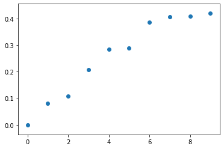

*Above: plot of eigenvalues*

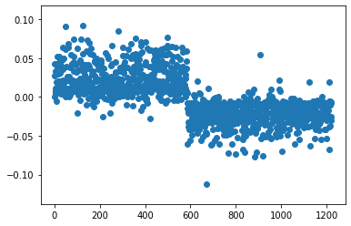

*Above: plot of the third eigenvector*

# 2. PCA

The data `food-consumption.csv` contains 16 countries in the European area and their consumption for 20 food items, such as tea, jam, coffee, yoghurt, and others. There are some missing data entries: you may remove the rows "Sweden", "Finland", and "Spain". The goal is to perform PCA analysis on the data, i.e., find a way to perform linear combinations of features across all 20 food-item consumptions, for each country. If we extract two principal components, that means we use two singular vectors that correspond to the largest singular values of the data matrix, in combining features. You will need to implement PCA by writing your own code.

## 2.1. Explanation of PCA

Write down the set-up of PCA for this setting. Explain how the data matrix is set-up in this case (e.g., each dimension of the matrix correspond to what.) Explain in words how PCA is performed in this setting.

Each dimension/feature in the data matrix represents countries' consumption of a specific food item: tea, biscuits, etc. Each row in the matrix represents a single country's consunmption of those food items.

PCA is performed by:

1. Centering/standardizing the different dimensions in the data matrix
2. Computing the covariance matrix from the standardized data matrix
3. Computing the eigenvectors associated with the $k$ greatest eigenvalues of the covariance matrix

The $k$ eigenvectors selected in step 3 are the principal components. $k < d$ (where $d$ is the number of dimensions/features in the original data), and is typically selected in order to capture a high percentage of variance.

The original data can also be represented in terms of the selected principal components by projecting the data matrix into the principal components' subspace.

## 2.2. Finding top $k$ principal components

Suppose we aim to find top $k$ principal components. Write down the mathematical optimization problem involved for solving this problem. Explain the procedure to find the top $k$ principal components in performing PCA.

The optimization problem is to select principal components $w$ that **maximize variation of the data along the direction of those eigenvectors**. This can be expressed as maximizing variance (i.e. mean sum of squared differences from the mean) when projecting data onto the principal components' subspace:

$$ max \ w^\top \left( \frac{1}{m}\sum_{i}^{m}(x_i-\mu)(x_i-\mu)^\top \right) $$

The set of all principal components are computed as the eigenvectors of the covariance matrix. Once the eigenvectors and eigenvalues are computed, sort the eigenvectors by the magnitude of their eigenvalues and choose the $k$ eigenvectors associated with the $k$ largest eigenvalues.

The value of $k$ can be chosen by balancing the amount of variation captured by those principal components against the number of dimensions in the reduced representation. Using all principal components would capture 100% of the variation, but fail to reduce dimensionality, which is the primary goal of PCA. There is no single rule for choosing a value for $k$, but visuals such as scree plots may help.

It is important to note that standardizing or centering the data is necessary unless every dimension has very similar ranges of values. This is because PCA aims to maximize variance; if one dimension has a much larger range of values, it will be over-weighted by PCA unless the values in that column of the data matrix are standardized.

## 2.3. Top 2 principal components

Find the top two principal component vectors for the dataset and plot them (plot a value of the vector as a one-dimensional function). Describe do you see any pattern.

**Full code for 2.3 and 2.4 is in the included Jupyter notebook (`wang_arthur_hw2_code.ipynb`).**

Plots of the magnitudes (absolute values of entries) of the top two principal components are shown below.

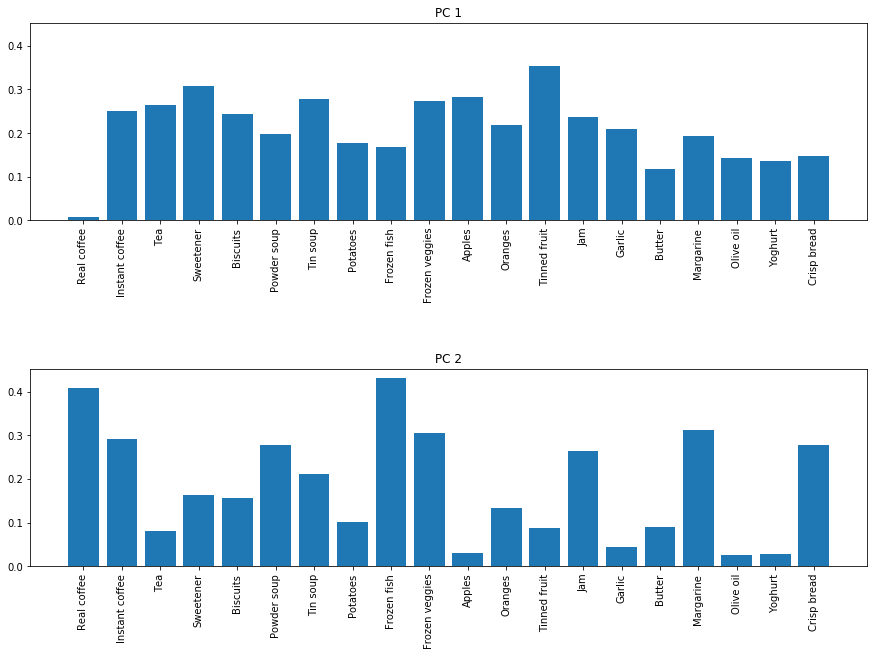

My observations:

- The first principal component's entries with the greatest magnitude correspond to tinned fruit, sweetener, apples, tin soup, and frozen veggies
- The second principal component's entries with the greatest magnitude correspond to frozen fish, real coffee, frozen veggies, and margarine
- PC 1 does not weigh any one entry more than others to the same extent that PC 2 does; the magnitude plot looks smoother and weighs the original dimensions more evenly

## 2.4. Projection using principal components

Now project each data point using the top two principal component vectors (thus now each data point will be represented using a two-dimensional vector). Draw a scatter plot of two-dimensional reduced representation for each country. What pattern can you observe?

A scatter plot of the reduced representation of each country is shown below.

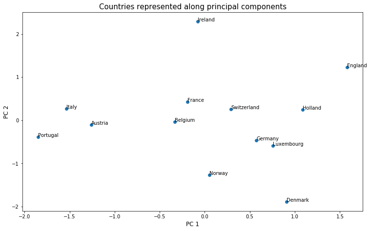

My observations: